# Can we trust rapid satellite damage maps?

A six-product, three-reference evaluation of the 2026 Venezuela earthquake

Z. Arno · L. Milano — OCHA Centre for Humanitarian Data

2026-07-28

## The situation

Within days of the M7.5 quake (24 June 2026), **eight+ organisations** published satellite building-damage maps — government (Copernicus), academic radar (OSU, IMPACT), optical AI (Microsoft, U. Houston, WFP/LIST), debris models (UNEP), volunteer AI (HOT, DISHA).

They **disagreed with each other, sometimes wildly.** A coordinator had no principled way to answer: *which do I trust, for what, and at what scale?*

**What we did** — scored the six products that published an analysed extent against **three reference datasets whose blind spots don’t overlap**, so they check each other and the products.

**Bottom line** — as delivered, most single products carried **less usable per-building information than a no-satellite baseline**. But they *are* good at ranking neighbourhoods, combining helps within limits, and the real leverage is **reference quality + provider transparency**.

## Three questions — kept strictly separate

- **1 · Where is it worst?** — ranking neighbourhoods for triage
- **2 · Which buildings?** — a list you could send a crew to
- **3 · What does everyone miss?** — including the “ground truth” itself

And two performance frames we **never mix**:

- **Best case** — Caraballeda, the dense-damage zone where **96% of the expert reference lives.** Where most published numbers implicitly come from.
- **As delivered** — the whole product, every zone it shipped, junk included. What a responder actually received.

That split is itself a finding.

## The three references — who they are

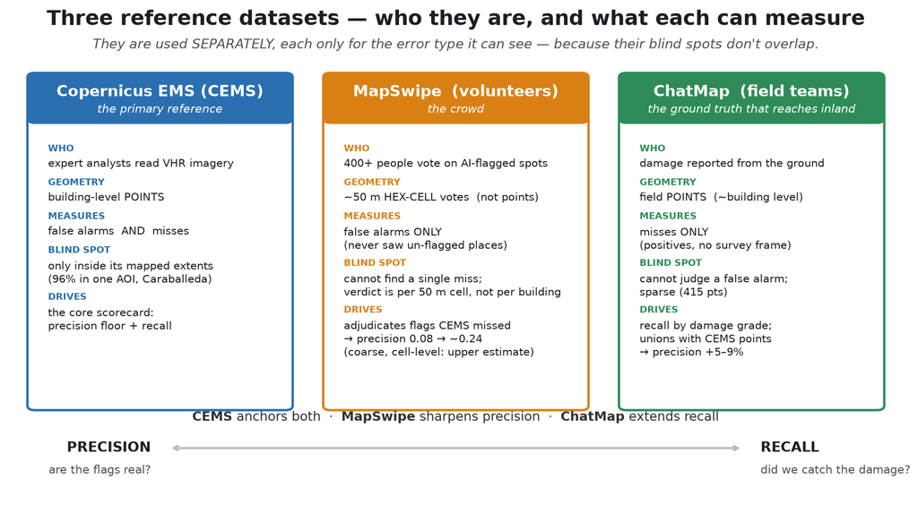

## How we score each product

- **Precision** — of the buildings a product *flagged*, how many are next to real (CEMS) damage? *(are its flags trustworthy?)*
- **Recall** — of the *real damage points*, how many did the product flag? *(how much did it catch?)*

A flag and a damage point count as a match within **10 m** (set by building spacing). Target throughout: buildings the expert graded **damaged or destroyed** — not destruction alone.

## How matching works

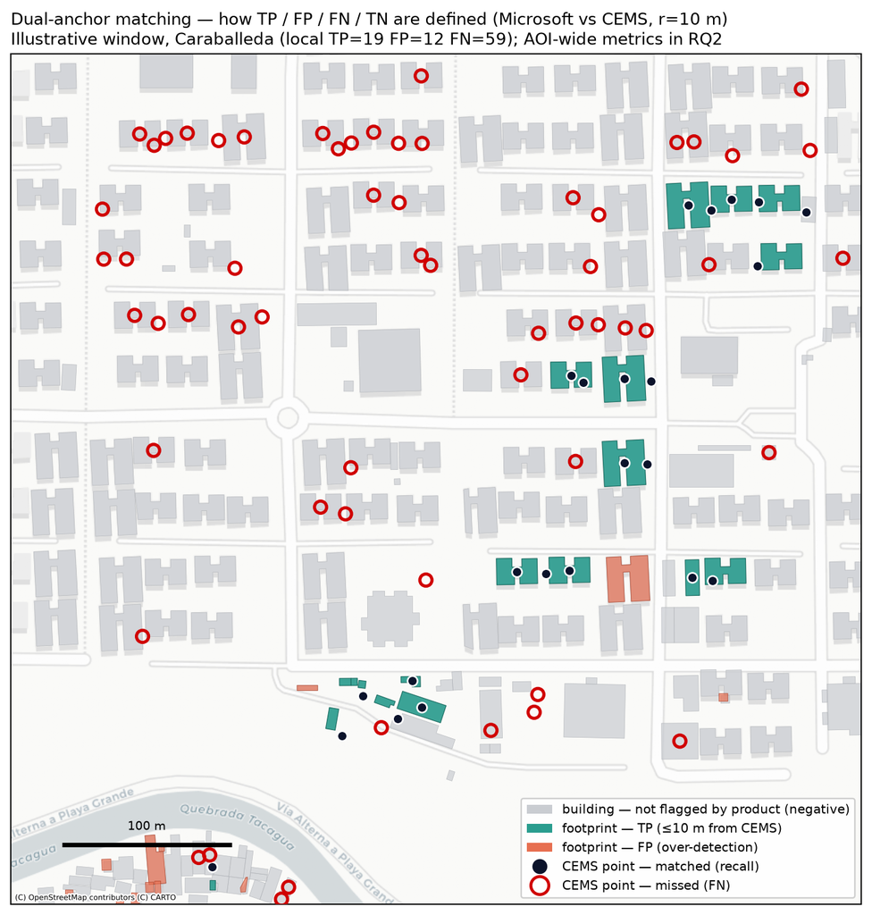

## Their most useful capability — ranking neighbourhoods

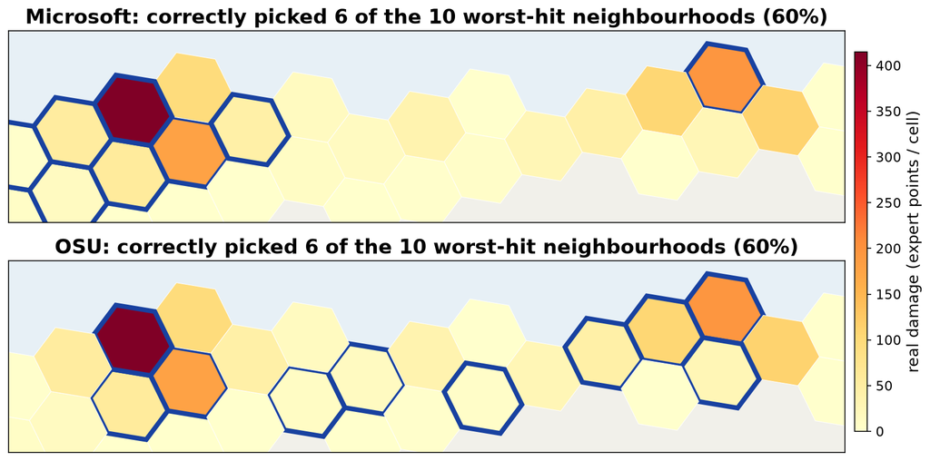

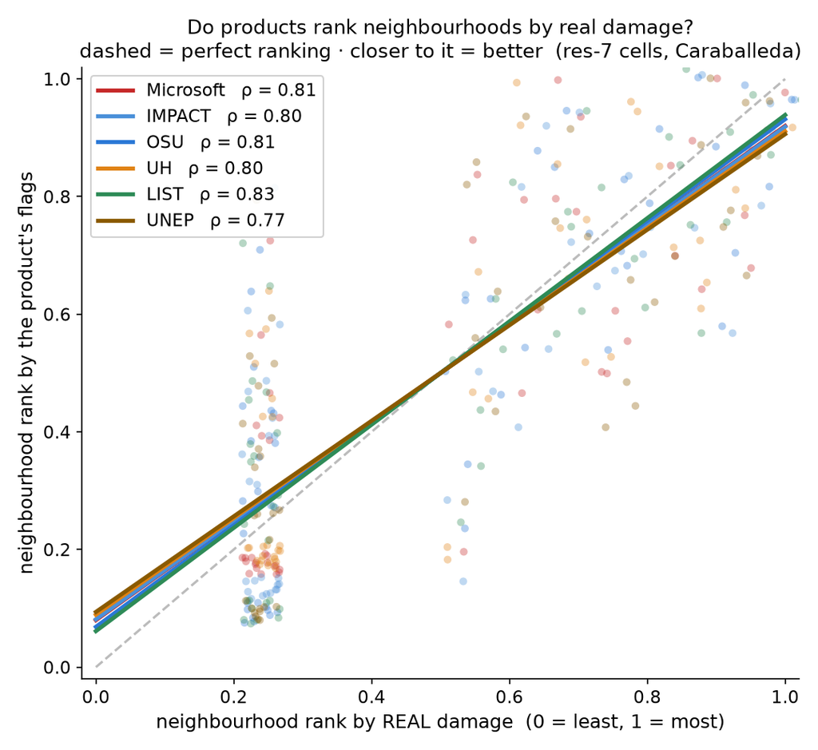

Left: each product’s worst-hit picks land on the really-damaged cells. Right: **all six products** rank neighbourhoods about equally well (ρ ≈ 0.77–0.83 within the damage zone) — closer to the dashed line = better.

## Where they struggle — the per-building list

Target: **damaged *or* destroyed** buildings (expert classes 2–3). In Caraballeda, where products score highest:

precision 0.04 – 0.09

Counting **only expert-recorded damage**, for every flag that hits, **10–20 miss.** *(Crediting damage the expert missed — from crowd/field data — cuts this to ~4–5; see the operating-cost slide. Same buildings, stricter vs. fairer scoring.)*

The benchmark that should worry us: a model given **only day-zero geography** — coast distance, building density, ShakeMap intensity, all available *before any satellite is tasked* — matches the best single product.

## The benchmark that should give us pause

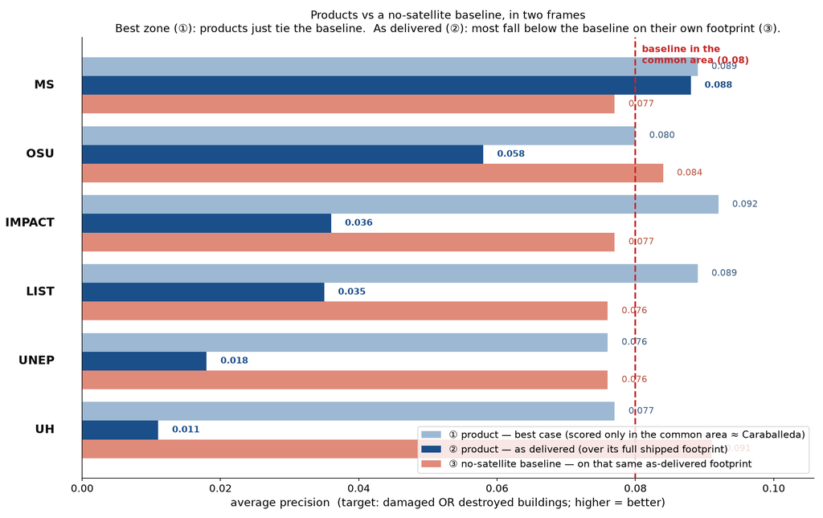

## The reference has its own blind spot

Recall vs the **415 ChatMap field reports** · grades: *complete / significant* · every row (incl. CEMS) scored against the ground

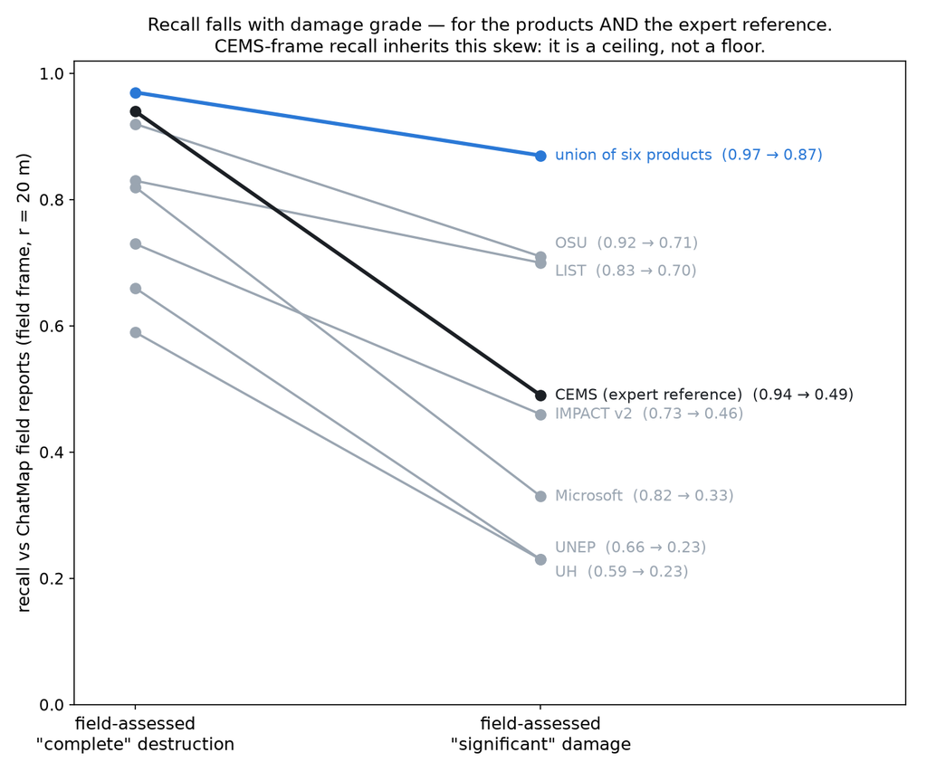

## The destruction bias shows in precision too

Different validation set: vs **CEMS’s own 1,467 points** · grades: *Damaged / Destroyed* · numbers not comparable to the previous slide — the shared message is the slope

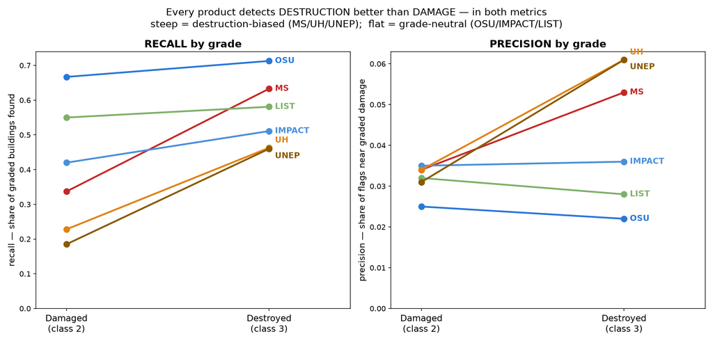

## One product is many scorecards

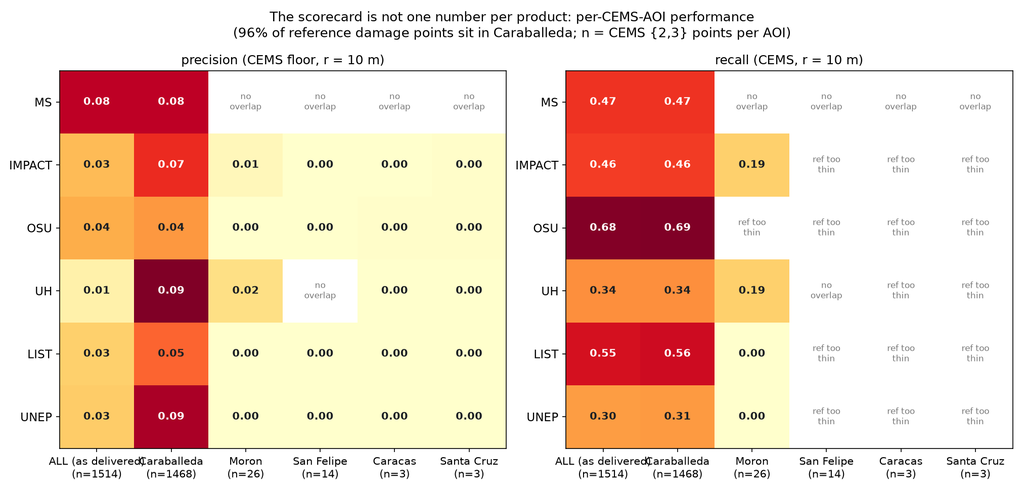

## Even within one product, performance flips across the coast

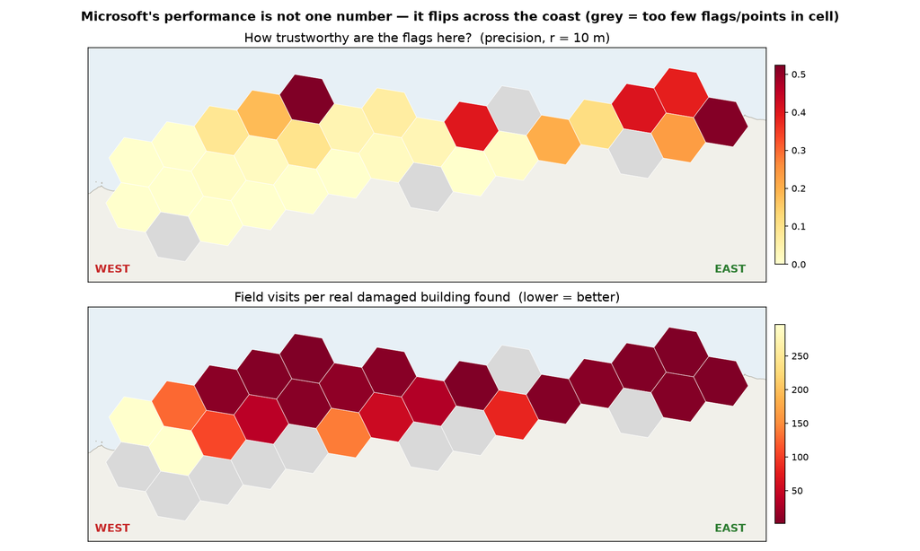

## Precision across Caraballeda, by product (1/2)

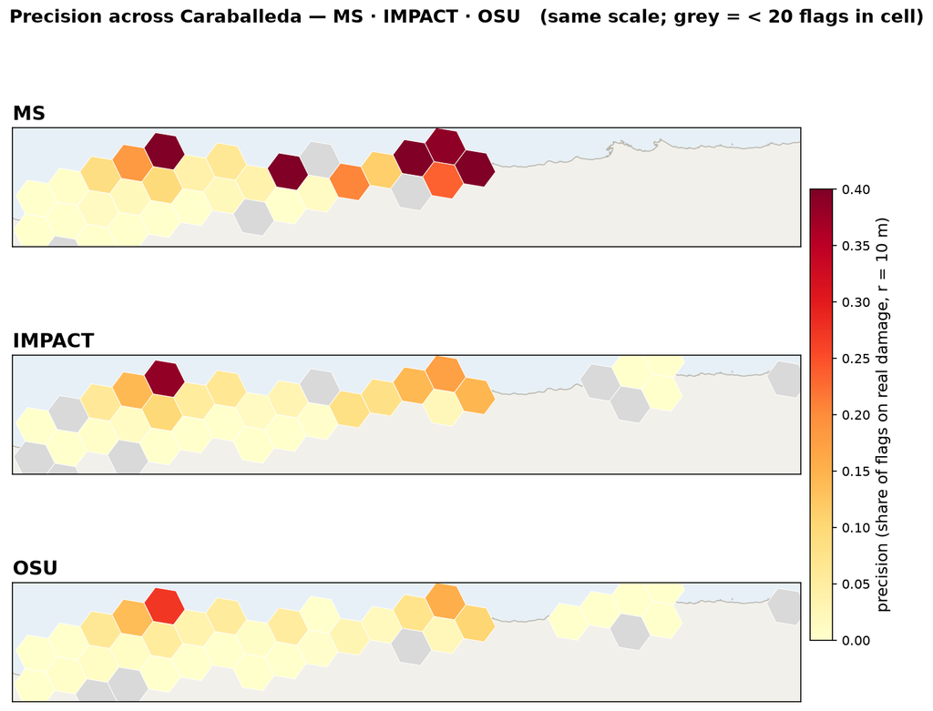

## Precision across Caraballeda, by product (2/2)

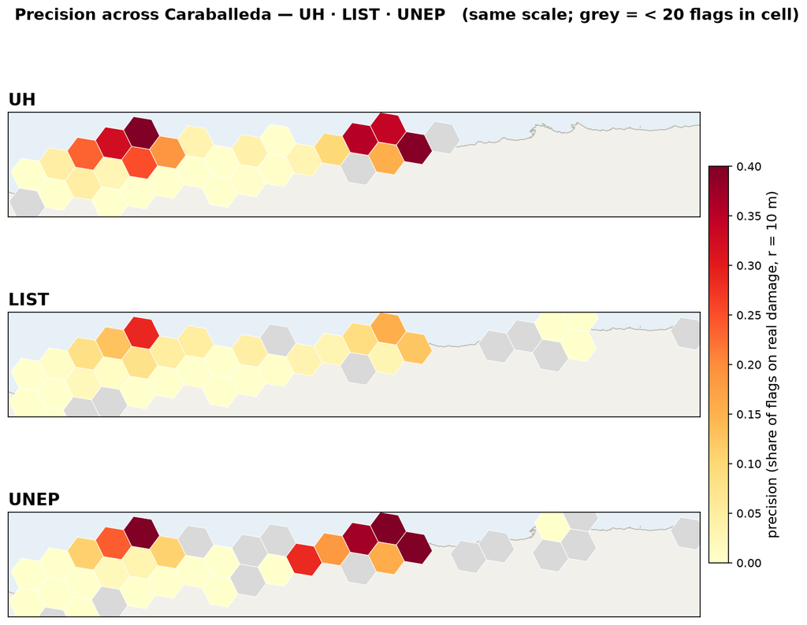

## Does combining products fix it? Partly.

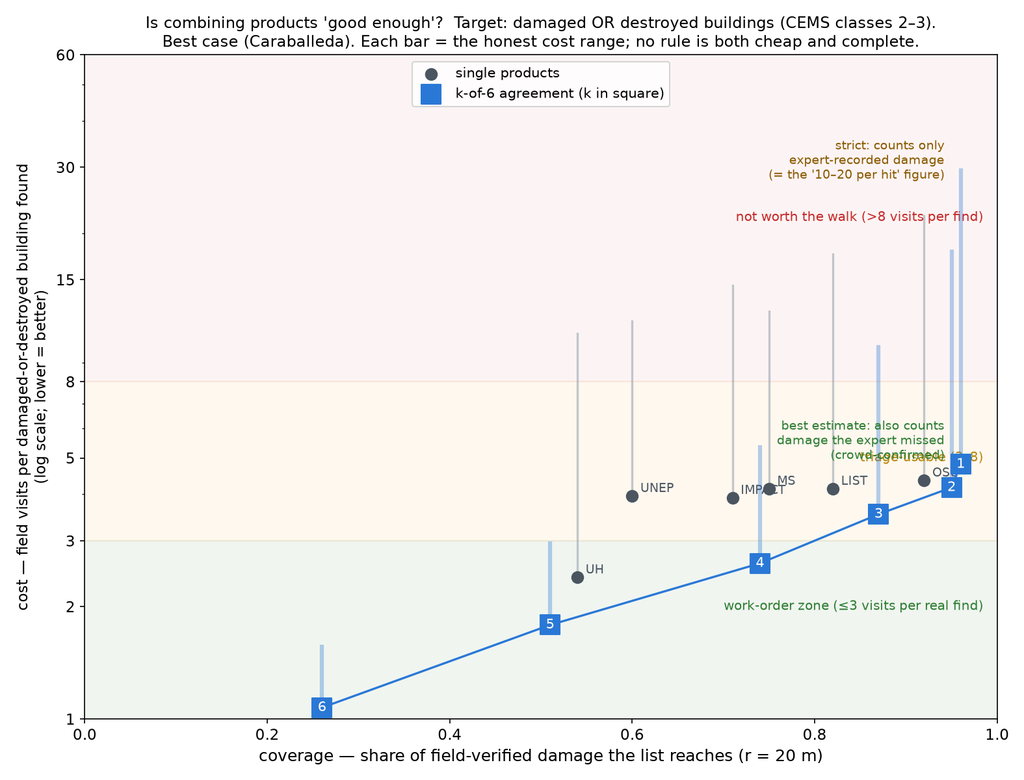

## Is the ensemble just “flagging fewer things”? No.

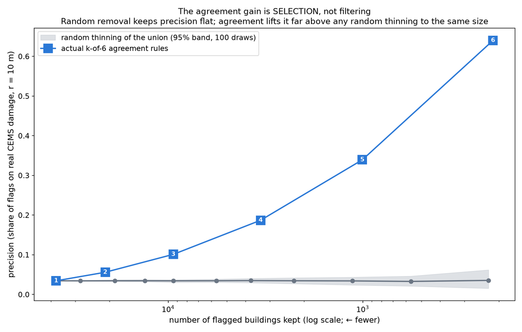

## Transparency lets you fix failures

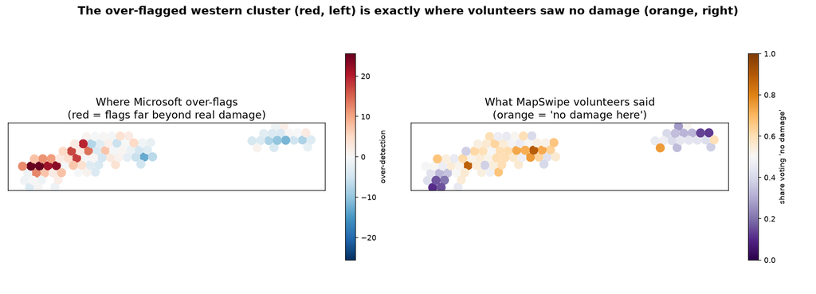

## What we would recommend

**Providers** — publish an analysed extent (non-negotiable); publish per-building provenance (scene count + dates); *scope* your coverage rather than blanket-ship; clear a geography-only baseline before release.

**Evaluators** — one expert reference under-counts light damage. Publish precision as a *floor*, or adjudicate against a second reference and publish an *interval*. Crowd and field data are first-class, not afterthoughts.

**Responders** — trust the *area ranking*, not the building counts; set the agreement dial to your own cost of a wasted visit vs. a missed building. Nothing here sees light damage reliably — plan shelter assessments accordingly.

## Where this is solid — and where it isn’t

**Solid** — six products, three independent references, ~1,500 lines of reproducible open code. The area-ranking win, the day-zero result, the per-zone collapse, and the west-cluster diagnosis all hold across frames.

**Honest limits:**

- **One event, one geography** (coastal, dense-urban); 96% of reference in one AOI.
- Outside Caraballeda the reference is too thin to cleanly separate product error from reference gaps — the as-delivered penalty leans on that.
- **No confidence intervals yet** — needed before leaning on the ±0.01 gaps.
- The **timeliness axis** (accuracy × how fast each product arrived) isn’t built yet — arguably the most decision-relevant variable.

## The asks

**1 · Back writing this up.** The framework — three-reference triangulation, the floor/ceiling correction, the geography baseline as a validation bar — is novel and travels beyond this event.

**2 · Support taking findings to providers.** Constructive and evidence-based; their own metadata is the hero. This strengthens the ecosystem, doesn’t just critique it.

**3 · Resource the two gaps that make it bulletproof** — confidence intervals, and the timeliness axis (needs provider release dates, an ask we can make together).

# Appendix

Backup slides for likely questions.

## Appendix — why precision falls outside Caraballeda

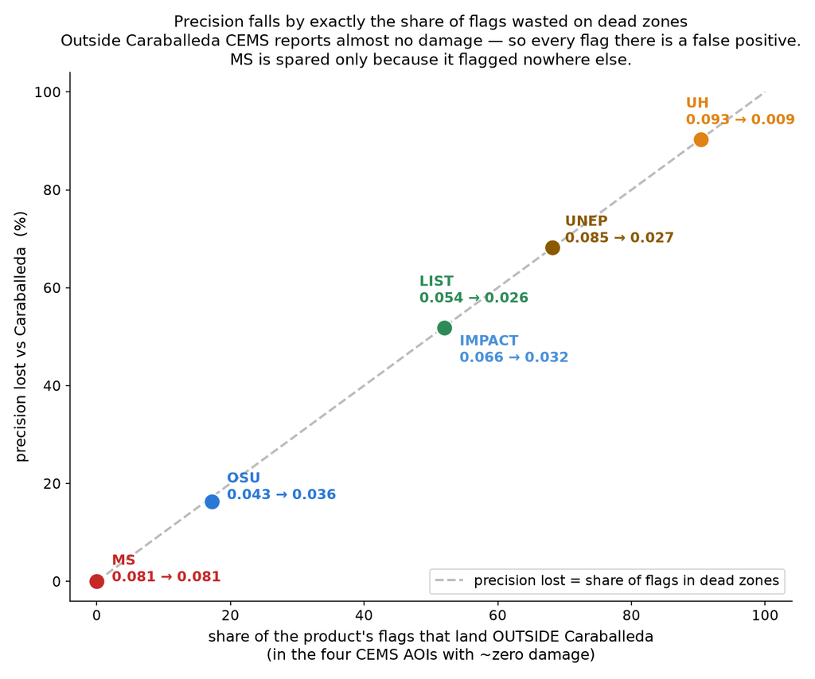

## Appendix — the strict numbers are floors

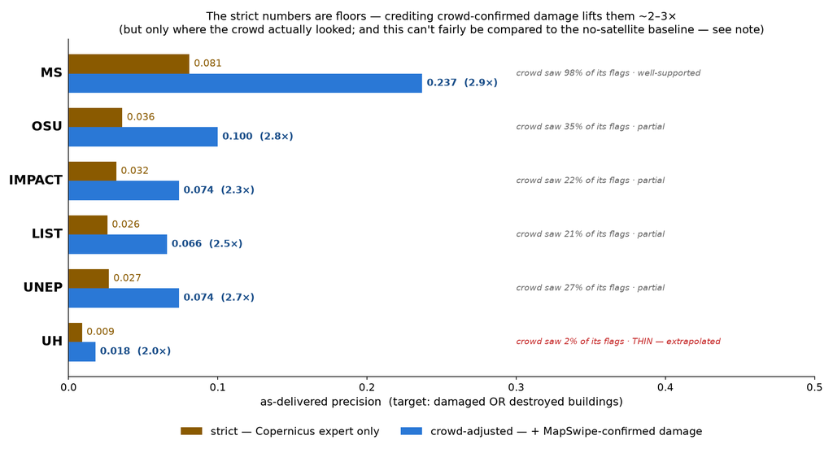